# Models & Data

## Language Models

#### **[Facebook bart-large-cnn](https://huggingface.co/facebook/bart-large-cnn) sequence-to-sequence model trained to summarise policy positions from party press releases**

LLM available at: z-dickson/bart-large-cnn-climate-change-summarization

**Details**

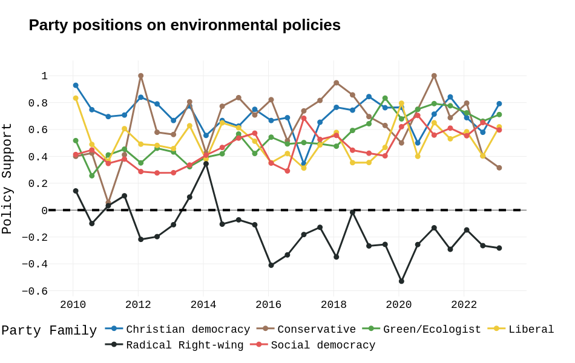

#### **[Vinai/bertweet-large](https://huggingface.co/vinai/bertweet-large) model trained to predict opposition to COVID-19 policies in US congressmembers’ tweets**

LLM available at: z-dickson/US_politicians_covid_skepticism

**Details**

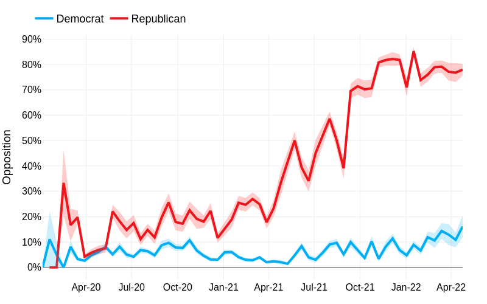

#### **[Bert-base-multilingual-cased](https://huggingface.co/bert-base-multilingual-cased) trained to predict the [CAP issue codes](https://www.comparativeagendas.net/pages/master-codebook) of political text (i.e. bills, speeches, tweets etc.)**

LLM available at: z-dickson/CAP_multilingual

**Details**

Language model trained to predict the CAP Issue Code of political text. The model was trained on the universe of coded data from the Comparative Agendas Project (huge thanks!) and can accurately predict the CAP code of political text in multiple languages and domains.

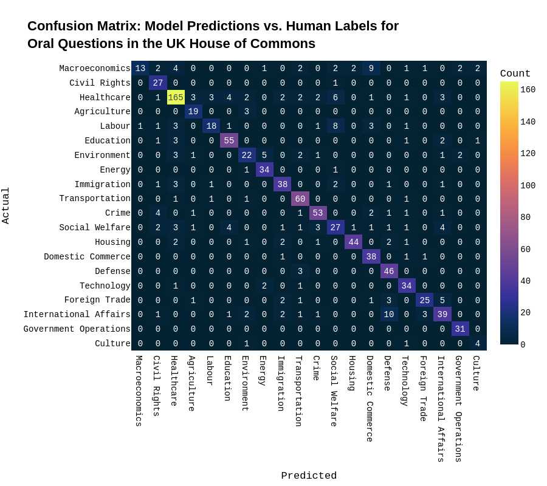

#### **[Bert-base-multilingual-cased](https://huggingface.co/bert-base-multilingual-cased) Sentiment model trained on Polish, English, Spanish, Dutch and German Newspaper headlines.**

LLM available at: z-dickson/multilingual_sentiment_newspaper_headlines

**Details**

Language model trained to predict the sentiment of newspaper headlines in English, Polish, Spanish, Dutch and German.

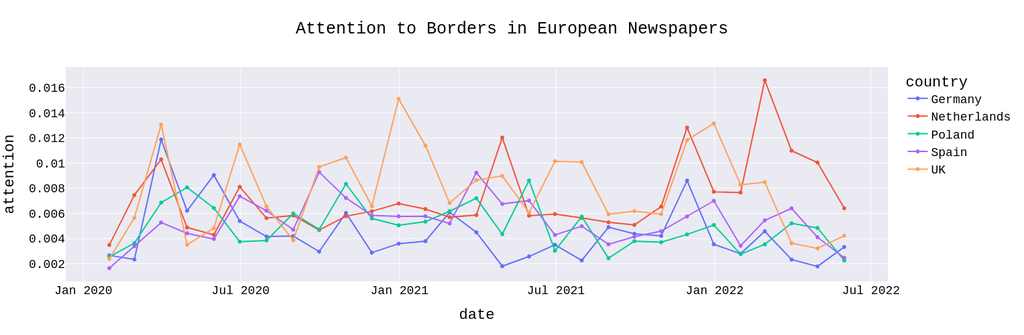

## Datasets

- UK Parliamentary Statutory Instruments: 1970-2021 [[github](https://github.com/z-dickson/UK_statutory_instruments)]
- Parliamentary Bills - Dáil Éireann (Ireland): 1950-2020 [[github](https://github.com/z-dickson/parliamentary_bills)]
- Parliamentary Bills - New Zealand Parliament: 1900-2020 [[github](https://github.com/z-dickson/parliamentary_bills)]